# Image Analysis: Facial Emotion Detection and Object Detection

The goal of this tutorial is to go through some basic image analysis for social scientists. In previous tutorials, we have some basics on how to train a DL model with transfer learning approach. We will use the same idea of transfer learning in this tutorial as well.

## Facial Emotion Recognition

We will use deepface framework in python. Deepface is a facial recognition and attributes analysis framework for python created by the artificial intelligence research group at Facebook in 2015. It is a hybrid face recognition framework that uses state-of-the-art models for analysis such as VGG-Face, Google Facenet, Facebook Deepface, all wrapped together in one. Check here for more information https://github.com/serengil/deepface

I also this intro is very informative, you can take a look: https://sefiks.com/2020/05/01/a-gentle-introduction-to-face-recognition-in-deep-learning/

```python
# to use deepface, we have to install it first
!pip install deepface # not if you use python3, check whether it is pip3 instead of pip
```

```python
from deepface import DeepFace
import matplotlib.pyplot as plt
import matplotlib
matplotlib.rcParams['font.size'] = 10
import cv2
```

Deepface provides API to do facial attribute analysis, including age, gender, facial expression (including angry, fear, neutral, sad, disgust, happy and surprise) and race (including asian, white, middle eastern, indian, latino and black) predictions. It is just a couple of lines of codes.

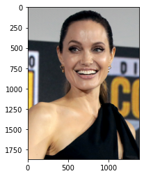

```python
# Let us extract some features from an image. Data are from <https://github.com/serengil/deepface>

img1 = cv2.imread("./dataset/img1.jpg")
plt.imshow(cv2.cvtColor(img1, cv2.COLOR_BGR2RGB))
```

```python
obj = DeepFace.analyze(img_path = "./dataset/img1.jpg", actions = ['age', 'gender', 'race', 'emotion'])
```

```python
print(obj)
```

[output not shown]

```python
# Let us plot the bounding box
region=obj["region"]
x = region["x"]
y=region["y"]
w=region["w"]
h=region["h"]
```

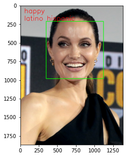

```python
fig, ax = plt.subplots(nrows=1, ncols=1, figsize=(5,5))

cv2.rectangle(img1, (x,y), (x+w,y+h), (0,255,0), 5)
cv2.putText(img1, obj['dominant_emotion'], (50,100), cv2.FONT_HERSHEY_SIMPLEX, 3, (0,0,255), 3, cv2.LINE_4)
cv2.putText(img1, obj['dominant_race'], (50,200), cv2.FONT_HERSHEY_SIMPLEX, 3, (0,0,255), 3, cv2.LINE_4)
plt.imshow(cv2.cvtColor(img1, cv2.COLOR_BGR2RGB))
```

## Facial Verification

You can also use deepface to verify whether two faces are identical

[figure not shown]

```python
img2 = cv2.imread("./dataset/img2.jpg")
plt.imshow(cv2.cvtColor(img2, cv2.COLOR_BGR2RGB))
```

```python
 veri_result = DeepFace.verify(img1_path = "./dataset/img1.jpg", img2_path = "./dataset/img2.jpg")
# it takes some time because it will download the pretrained vgg face model. You can use different models
```

```python
 veri_result
```

```
{'verified': True,
 'distance': 0.25551898252856886,
 'threshold': 0.4,
 'model': 'VGG-Face',
 'detector_backend': 'opencv',
 'similarity_metric': 'cosine'}
```

```python
# Deepface is a hybrid face recognition package.
# It currently wraps many state-of-the-art face recognition models:
# VGG-Face , Google FaceNet, OpenFace, Facebook DeepFace, DeepID, ArcFace, Dlib and SFace.
# The default configuration uses VGG-Face model.

models = ["VGG-Face", "Facenet", "Facenet512", "OpenFace", "DeepFace", "DeepID", "ArcFace", "Dlib", "SFace"]

#face verification
facenet_result = DeepFace.verify(img1_path = "./dataset/img1.jpg", img2_path = "./dataset/img2.jpg", model_name = models[2])
```

```python
facenet_result
```

```
{'verified': True,
 'distance': 0.23241935528833846,
 'threshold': 0.3,
 'model': 'Facenet512',
 'detector_backend': 'opencv',
 'similarity_metric': 'cosine'}
```

## Facial Detection

Face recognition requires applying face verification many times. Herein, deepface has an out-of-the-box find function to handle this action. It's going to look for the identity of input image in the database path and it will return pandas data frame as output.

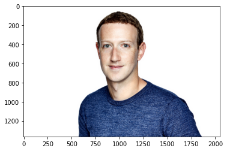

```python
# the dataset contains a bunch of images

import glob
images = glob.glob("./dataset/*jpg")
images

def process(filename):
    image = cv2.imread(filename)
    plt.imshow(cv2.cvtColor(image, cv2.COLOR_BGR2RGB))
    plt.show()

for file in images:
    process(file)
```

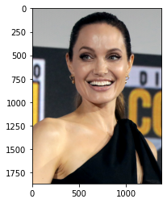

```python
# Let us find all images matching img1
img1 = cv2.imread("./dataset/img1.jpg")
plt.imshow(cv2.cvtColor(img1, cv2.COLOR_BGR2RGB))
plt.show()
```

```python
df = DeepFace.find(img_path = "./dataset/img1.jpg", db_path = "./dataset")
```

```
WARNING: Representations for images in  ./dataset  folder were previously stored in  representations_vgg_face.pkl . If you added new instances after this file creation, then please delete this file and call find function again. It will create it again.
There are  61  representations found in  representations_vgg_face.pkl
find function lasts  1.5316097736358643  seconds
```

```python
df
```

|  | identity | VGG-Face_cosine |
| --- | --- | --- |
| 0 | ./dataset/img1.jpg | 7.771561e-16 |
| 1 | ./dataset/img4.jpg | 2.363995e-01 |
| 2 | ./dataset/img2.jpg | 2.555190e-01 |
| 3 | ./dataset/img6.jpg | 2.973867e-01 |
| 4 | ./dataset/img7.jpg | 3.116518e-01 |
| 5 | ./dataset/img5.jpg | 3.180218e-01 |
| 6 | ./dataset/img11.jpg | 3.577461e-01 |
| 7 | ./dataset/img10.jpg | 3.812147e-01 |

## Object Detection

We will use yolo5 to do some object detection. For more details about the tutorial, please check https://github.com/ultralytics/yolov5

YOLO5 provides a series of pretrained models. You can access via torch.hub

Here we just simply show how you can use their models to do object detection. But if you have own object data, you need to do some custom training using the idea of transfer learning. You can check here for more details: https://github.com/ultralytics/yolov5/wiki/Train-Custom-Data

```python
!pip install torch
```

```python
import torch

# Model
model = torch.hub.load('ultralytics/yolov5', 'yolov5s')  # or yolov5n - yolov5x6, custom

# Images
img = './dataset/img7.jpg'  # or file, Path, PIL, OpenCV, numpy, list

# Inference
results = model(img)

# Results
results.print()  # or .show(), .save(), .crop(), .pandas(), etc.
```

```
Using cache found in /Users/joshzyj/.cache/torch/hub/ultralytics_yolov5_master
YOLOv5 🚀 2022-7-7 Python-3.8.12 torch-1.10.1 CPU

Fusing layers...
YOLOv5s summary: 213 layers, 7225885 parameters, 0 gradients
Adding AutoShape...
```

```
image 1/1: 2048x1363 1 person, 1 bird
Speed: 59.9ms pre-process, 196.0ms inference, 0.8ms NMS per image at shape (1, 3, 640, 448)
```

```python
results.show()
```

[output not shown]

The End. Hope you enjoy it.